# Class 09 Structural Bioinformatics 1

There has been lots of work done on this protein due to it’s importance including lots of crystal structure.

```r
library(bio3d)
```

```r
aa <- get.seq("1ake_A")
```

```
## Fetching... Please wait. Done.
```

```r
aa
```

```
##              1        .         .         .         .         .         60
## pdb|1AKE|A   MRIILLGAPGAGKGTQAQFIMEKYGIPQISTGDMLRAAVKSGSELGKQAKDIMDAGKLVT
##              1        .         .         .         .         .         60
##
##             61        .         .         .         .         .         120
## pdb|1AKE|A   DELVIALVKERIAQEDCRNGFLLDGFPRTIPQADAMKEAGINVDYVLEFDVPDELIVDRI
##             61        .         .         .         .         .         120
##
##            121        .         .         .         .         .         180
## pdb|1AKE|A   VGRRVHAPSGRVYHVKFNPPKVEGKDDVTGEELTTRKDDQEETVRKRLVEYHQMTAPLIG
##            121        .         .         .         .         .         180
##
##            181        .         .         .   214
## pdb|1AKE|A   YYSKEAEAGNTKYAKVDGTKPVAEVRADLEKILG
##            181        .         .         .   214
##
## Call:
##   read.fasta(file = outfile)
##
## Class:
##   fasta
##
## Alignment dimensions:
##   1 sequence rows; 214 position columns (214 non-gap, 0 gap)
##
## + attr: id, ali, call
```

We can now run BLAST with this sequence

```r
b <- blast.pdb(aa)
```

```
##  Searching ... please wait (updates every 5 seconds) RID = 5N2Z4DM9013
##  ....
##  Reporting 82 hits
```

```
##   * Possible cutoff values:    197 11
##             Yielding Nhits:    16 82
##
##   * Chosen cutoff value of:    197
##             Yielding Nhits:    16
```

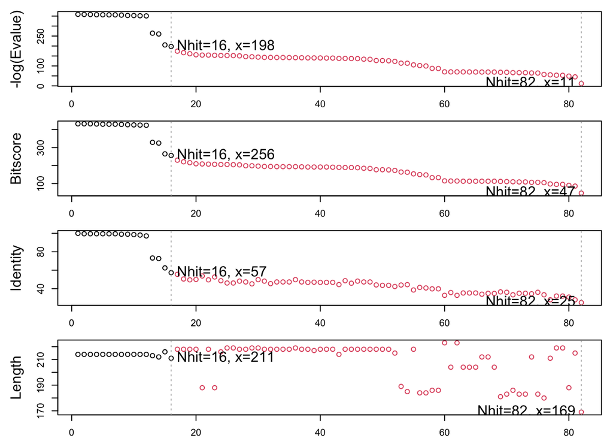

```r
hits <- plot(b)
```

Let’s see whats it our ‘hits’

```r
#hits$pdb.id
```

Now we can download all these PDB structure files:

```r
files <- get.pdb(hits$pdb.id, path="pdbs", split=TRUE, gzip=TRUE)
```

Now i want to align and superimpose these structures which are all over the place.

```r
# Align releated PDBs
pdbs <- pdbaln(files, fit = TRUE, exefile="msa")
```

[output not shown]

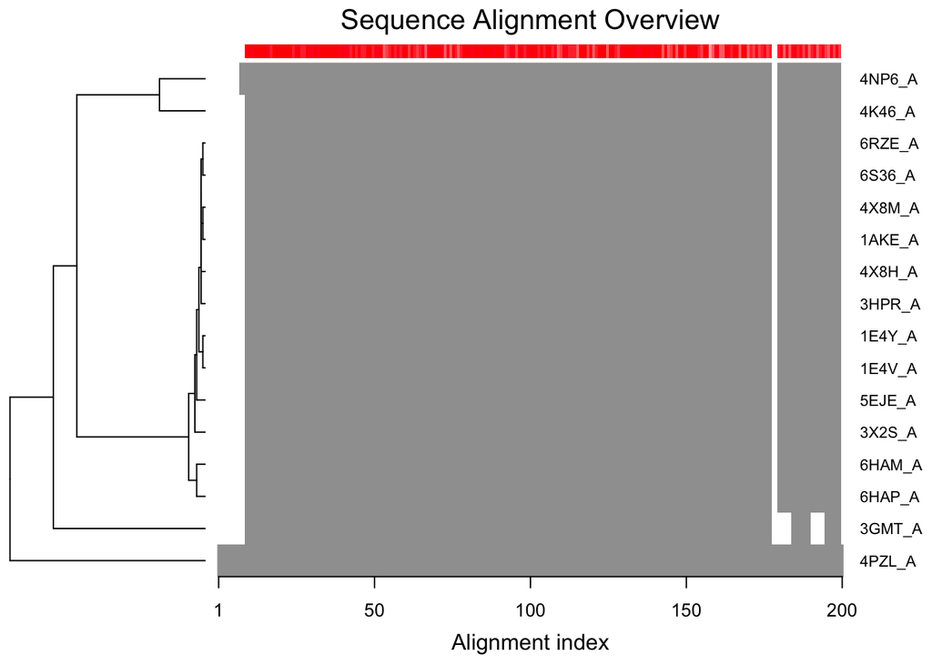

```r
# Vector containing PDB codes for figure axis
ids <- basename.pdb(pdbs$id)

# Draw schematic alignment
plot(pdbs, labels=ids)
```

```r
#annotate
anno <- pdb.annotate(ids)
unique(anno$source)
```

```
## [1] "Escherichia coli"
## [2] "Escherichia coli K-12"
## [3] "Escherichia coli O139:H28 str. E24377A"
## [4] "Escherichia coli str. K-12 substr. MDS42"
## [5] "Photobacterium profundum"
## [6] "Vibrio cholerae O1 biovar El Tor str. N16961"
## [7] "Burkholderia pseudomallei 1710b"
## [8] "Francisella tularensis subsp. tularensis SCHU S4"
```

```r
anno
```

```
##        structureId chainId macromoleculeType chainLength experimentalTechnique
## 1AKE_A        1AKE       A           Protein         214                 X-ray
## 4X8M_A        4X8M       A           Protein         214                 X-ray
## 6S36_A        6S36       A           Protein         214                 X-ray
## 6RZE_A        6RZE       A           Protein         214                 X-ray
## 4X8H_A        4X8H       A           Protein         214                 X-ray
## 3HPR_A        3HPR       A           Protein         214                 X-ray
## 1E4V_A        1E4V       A           Protein         214                 X-ray
## 5EJE_A        5EJE       A           Protein         214                 X-ray
## 1E4Y_A        1E4Y       A           Protein         214                 X-ray
## 3X2S_A        3X2S       A           Protein         214                 X-ray
## 6HAP_A        6HAP       A           Protein         214                 X-ray
## 6HAM_A        6HAM       A           Protein         214                 X-ray
## 4K46_A        4K46       A           Protein         214                 X-ray
## 4NP6_A        4NP6       A           Protein         217                 X-ray
## 3GMT_A        3GMT       A           Protein         230                 X-ray
## 4PZL_A        4PZL       A           Protein         242                 X-ray
##        resolution       scopDomain                   pfam         ligandId
## 1AKE_A      2.000 Adenylate kinase Adenylate kinase (ADK)              AP5
## 4X8M_A      2.600             <NA> Adenylate kinase (ADK)             <NA>
## 6S36_A      1.600             <NA> Adenylate kinase (ADK) CL (3),MG (2),NA
## 6RZE_A      1.690             <NA> Adenylate kinase (ADK)    NA (3),CL (2)
## 4X8H_A      2.500             <NA> Adenylate kinase (ADK)             <NA>
## 3HPR_A      2.000             <NA> Adenylate kinase (ADK)              AP5
## 1E4V_A      1.850 Adenylate kinase Adenylate kinase (ADK)              AP5
## 5EJE_A      1.900             <NA> Adenylate kinase (ADK)           AP5,CO
## 1E4Y_A      1.850 Adenylate kinase Adenylate kinase (ADK)              AP5
## 3X2S_A      2.800             <NA> Adenylate kinase (ADK)   JPY (2),AP5,MG
## 6HAP_A      2.700             <NA> Adenylate kinase (ADK)              AP5
## 6HAM_A      2.550             <NA> Adenylate kinase (ADK)              AP5
## 4K46_A      2.010             <NA> Adenylate kinase (ADK)      ADP,AMP,PO4
## 4NP6_A      2.004             <NA> Adenylate kinase (ADK)             <NA>
## 3GMT_A      2.100             <NA> Adenylate kinase (ADK)          SO4 (2)
## 4PZL_A      2.100             <NA> Adenylate kinase (ADK)       FMT,CA,GOL
##                                                                              ligandName
## 1AKE_A                                                 BIS(ADENOSINE)-5'-PENTAPHOSPHATE
## 4X8M_A                                                                             <NA>
## 6S36_A                                    CHLORIDE ION (3),MAGNESIUM ION (2),SODIUM ION
## 6RZE_A                                                  SODIUM ION (3),CHLORIDE ION (2)
## 4X8H_A                                                                             <NA>
```

[output cut: 64 more lines]

```
## 4X8M_A 0.24630    C 1 2 1
## 6S36_A 0.15940    C 1 2 1
## 6RZE_A 0.18190    C 1 2 1
## 4X8H_A 0.19140    C 1 2 1
## 3HPR_A 0.20620  P 21 21 2
## 1E4V_A 0.19600  P 21 2 21
## 5EJE_A 0.18630  P 21 2 21
## 1E4Y_A 0.17800   P 1 21 1
## 3X2S_A 0.20700 P 21 21 21
## 6HAP_A 0.22370    I 2 2 2
## 6HAM_A 0.20311       P 43
## 4K46_A 0.16730 P 21 21 21
## 4NP6_A 0.18600       P 43
## 3GMT_A 0.23500   P 1 21 1
## 4PZL_A 0.19130       P 32
```

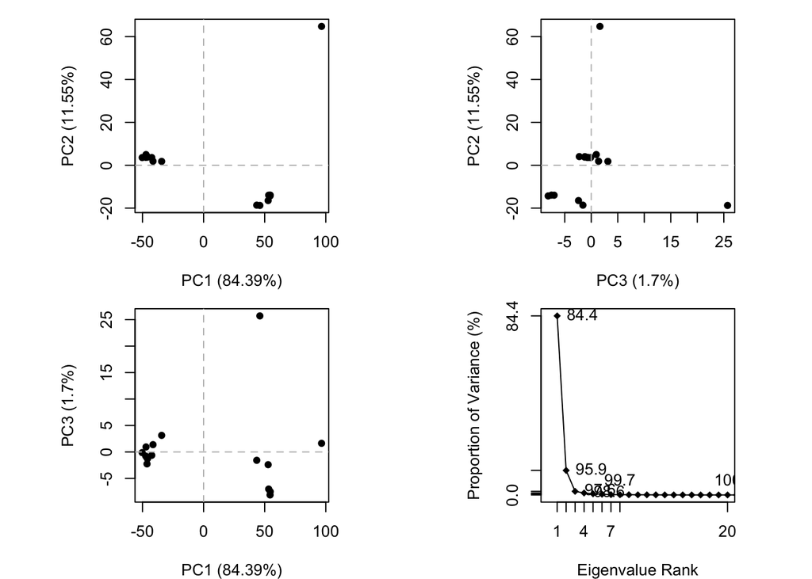

```r
# Perform PCA
pc.xray <- pca(pdbs)
plot(pc.xray)
```

```r
# Calculate RMSD
rd <- rmsd(pdbs)
```

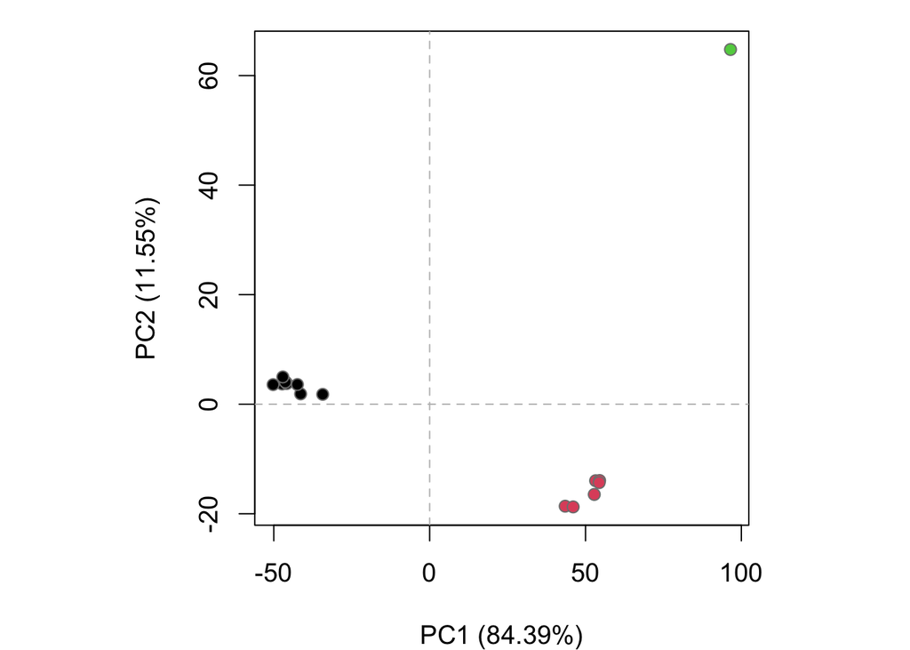

```r
# Structure-based clustering
hc.rd <- hclust(dist(rd))
grps.rd <- cutree(hc.rd, k=3)

plot(pc.xray, 1:2, col="grey50", bg=grps.rd, pch=21, cex=1)
```

We can make a wee movie - also called a trajectory of the major differences (ie structural displacements) of ADK.

```r
#Visualize first principal component makes a file of the protein in mol view
pc1 <- mktrj(pc.xray, pc=1, file="pc_1.pdb")
```

Bio3D-view > Q12. True or False? Functions from the devtools package can be used to install packages from GitHub and BitBucket?

true